# Exploratory_Data_analysis

# Re-formatting

We will group all the replicates for a specific condition together, grouping all replicates for high water level and all replicates for low water in the same population.

```r
sample_id<-Cs(Bui1H, Bui2H, Bui3H, Bui4H, Bui1L, Bui2L, Bui3L, Bui4L, Can1H, Can2H, Can3H, Can4H, Can1L, Can2L, Can3L, Can4L, Tur1H, Tur2H, Tur3H, Tur4H, Tur1L, Tur2L, Tur3L, Tur4L, Esp1H, Esp2H, Esp3H, Esp4H, Esp1L, Esp2L, Esp3L, Esp4L, Jab1H, Jab2H, Jab3H, Jab4H, Jab1L, Jab2L, Jab3L, Jab4L, Lla1H, Lla2H, Lla3H, Lla4H, Lla1L, Lla2L, Lla3L, Lla4L)

length(sample_id)
```

```
## [1] 48
```

```r
if(length(sample_id) == ncol(txi_filtered$counts)) {
  # Reorder the columns for counts, abundance, and length matrices within the list
  txi_filtered$counts <- txi_filtered$counts[, sample_id, drop = FALSE]
  txi_filtered$abundance <- txi_filtered$abundance[, sample_id, drop = FALSE]
  txi_filtered$length <- txi_filtered$length[, sample_id, drop = FALSE]
} else {
  stop("The length of the sample_id vector does not match the number of columns in the txi_filtered$counts matrix.")
}


class(txi_filtered)
```

```
## [1] "list"
```

```r
lapply(X=txi_filtered, FUN=head)
```

```
## $abundance
##                   Bui1H    Bui2H    Bui3H    Bui4H    Bui1L    Bui2L     Bui3L
## PECUL23A000004 5.834622  8.61568  5.73133 13.96135 11.26573 14.12998  5.669544
## PECUL23A000005 0.000000  0.00000  0.00000  0.00000  0.00000  0.00000  0.000000
## PECUL23A000006 0.000000  0.00000  0.00000  0.00000  0.00000  0.00000  0.000000
## PECUL23A000008 0.000000  0.00000  0.00000  0.00000  0.00000  0.00000  0.000000
## PECUL23A000011 8.092175 11.33848 13.18703 13.28496 12.37448 13.44365 11.989829
## PECUL23A000012 0.000000  0.00000  0.00000  0.00000  0.00000  0.00000  0.000000
##                   Bui4L     Can1H    Can2H     Can3H     Can4H     Can1L
## PECUL23A000004  8.83796  5.635945 5.655738  7.064038  6.712126  5.199612
## PECUL23A000005  0.00000  0.000000 0.000000  0.000000  0.000000  0.000000
## PECUL23A000006  0.00000  0.000000 0.000000  0.000000  0.000000  0.000000
## PECUL23A000008  0.00000  0.000000 0.000000  0.000000  0.000000  0.000000
## PECUL23A000011 12.77594 12.348997 8.870764 12.680745 11.607062 10.011978
## PECUL23A000012  0.00000  0.000000 0.000000  0.000000  0.000000  0.000000
##                   Can2L    Can3L     Can4L     Tur1H    Tur2H    Tur3H
## PECUL23A000004 5.372296 11.01083  7.282284  5.663375 8.135632 13.49882
## PECUL23A000005 0.000000  0.00000  0.000000  0.000000 0.000000  0.00000
## PECUL23A000006 0.000000  0.00000  0.000000  0.000000 0.000000  0.00000
## PECUL23A000008 0.000000  0.00000  0.000000  0.068550 0.000000  0.00000
## PECUL23A000011 9.557874  9.33566 11.634357 11.122779 8.002676 14.80203
## PECUL23A000012 0.000000  0.00000  0.000000  0.000000 0.000000  0.00000
##                    Tur4H     Tur1L     Tur2L    Tur3L     Tur4L     Esp1H
## PECUL23A000004  8.033623  7.139219  6.839344 12.87663  5.566241  4.516577
## PECUL23A000005  0.000000  0.000000  0.000000  0.00000  0.000000  0.000000
## PECUL23A000006  0.000000  0.000000  0.000000  0.00000  0.000000  0.000000
## PECUL23A000008  0.000000  0.000000  0.068696  0.00000  0.000000  0.000000
## PECUL23A000011 16.657202 14.500042 10.394990 11.17532 17.011485 12.899768
## PECUL23A000012  0.000000  0.000000  0.000000  0.00000  0.000000  0.000000
##                   Esp2H     Esp3H     Esp4H     Esp1L    Esp2L     Esp3L
## PECUL23A000004  5.52141  6.065409  5.746763  6.216259 5.542892  5.447331
## PECUL23A000005  0.00000  0.000000  0.000000  0.000000 0.000000  0.000000
## PECUL23A000006  0.00000  0.000000  0.000000  0.000000 0.000000  0.000000
## PECUL23A000008  0.00000  0.000000  0.000000  0.000000 1.292551  0.000000
## PECUL23A000011 13.45319 11.711039 10.597771 11.438218 9.735018 10.693385
## PECUL23A000012  0.00000  0.000000  0.000000  0.000000 0.000000  0.000000
##                   Esp4L     Jab1H     Jab2H    Jab3H    Jab4H    Jab1L
## PECUL23A000004  8.18186  5.936808  3.724884 10.70114 10.87945  5.85639
## PECUL23A000005  0.00000  0.000000  0.000000  0.00000  0.00000  0.00000
## PECUL23A000006  0.00000  0.000000  0.000000  0.00000  0.00000  0.00000
```

[output cut: 128 more lines]

```
## PECUL23A000005   68.64296   68.64296   68.64296   68.64296   68.64296
## PECUL23A000006  545.82808  545.82808  545.82808  545.82808  545.82808
## PECUL23A000008 1019.94632 1016.38600 1019.94632 1019.94632 1019.94632
## PECUL23A000011 4248.19548 4241.33077 4216.31185 4242.49553 4172.35051
## PECUL23A000012  445.89281  445.89281  445.89281  445.89281  445.89281
##                     Lla2L      Lla3L      Lla4L
## PECUL23A000004 6456.74557 6188.54541 6321.94211
## PECUL23A000005   68.64296   68.64296   68.64296
## PECUL23A000006  545.82808  545.82808  545.82808
## PECUL23A000008 1019.94632 1018.57800 1024.54800
## PECUL23A000011 4250.67093 4197.57433 4248.91279
## PECUL23A000012  445.89281  445.89281  445.89281
##
## $countsFromAbundance
## [1] "no"
```

# Creating the Experimental Design

```r
# Creating the vectors for the conditions.

waterLevel <- rep(c(rep("high",4), rep("low",4)), 6)
region <- c(rep("Central_Spain", 24), rep("Southern_Spain", 24))
populations <- c(rep("Buitrago",8), rep("Canencia",8), rep("Turrubuelo",8), rep("Espajosas",8), rep("Jabata",8), rep("Llano",8))


# Ensuring that all columns are treated as factors.

waterLevel <- factor(waterLevel, levels=c("high", "low"))
region <- factor(region, levels=c("Central_Spain", "Southern_Spain"))
populations <- factor(populations, levels=c("Buitrago", "Canencia", "Turrubuelo", "Espajosas", "Jabata", "Llano"))

class(waterLevel)
```

```
## [1] "factor"
```

```r
class(region)
```

```
## [1] "factor"
```

```r
class(populations)
```

```
## [1] "factor"
```

```r
# Building the data frame

exp_design<-data.frame(sample_id, waterLevel, region, populations)
colnames(exp_design)<-c("sample_id", "waterLevel", "region", "populations")
# row.names(exp_design)<-NULL

# Visualizing the resulting data frame

exp_design
```

```
##    sample_id waterLevel         region populations
## 1      Bui1H       high  Central_Spain    Buitrago
## 2      Bui2H       high  Central_Spain    Buitrago
## 3      Bui3H       high  Central_Spain    Buitrago
## 4      Bui4H       high  Central_Spain    Buitrago
## 5      Bui1L        low  Central_Spain    Buitrago
## 6      Bui2L        low  Central_Spain    Buitrago
## 7      Bui3L        low  Central_Spain    Buitrago
## 8      Bui4L        low  Central_Spain    Buitrago
## 9      Can1H       high  Central_Spain    Canencia
## 10     Can2H       high  Central_Spain    Canencia
## 11     Can3H       high  Central_Spain    Canencia
## 12     Can4H       high  Central_Spain    Canencia
## 13     Can1L        low  Central_Spain    Canencia
## 14     Can2L        low  Central_Spain    Canencia
```

[output cut: 34 more lines]

```r
write.table(exp_design, file="exp_design.csv", sep=",", row.names = F, col.names = T)
```

# Exploratory Analysis

Let’s have a look at the distribution of the data. We will use a logarithm transformation to better visualize the data. This way, we will not include zero counts, but these are not that relevant to visualize the data distribution.

The X-axis indicates the order of magnitude of the abundances, while the Y-axis (frequency) indicates the amount of genes/transcripts that have that specific abundance.

Visualize for the first sample.

[figure not shown]

```r
hist(log10(txi_filtered$abundance[,1]), breaks=50, main = "Abundance Distribution for Sample 1 - Bui1L", xlab = "log(abundances)", ylab = "Frequency")
```

Visualization of all sample_id’s abundances.

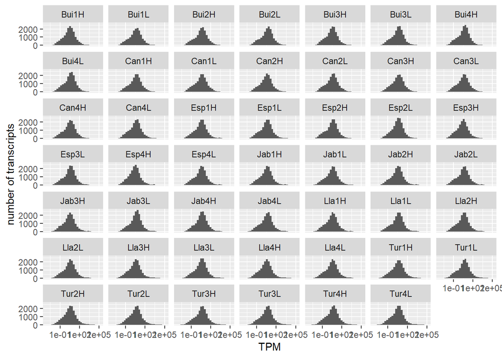

```r
# a more detailed plot with the tidyverse:
txi_filtered$abundance %>%
  #
  as_tibble(rownames = "transcript") %>%
  pivot_longer(-transcript, names_to="sample_id", values_to="TPM") %>%
  ggplot(aes(x=TPM)) +
  geom_histogram() +
  ylab("number of transcripts") +
  scale_x_log10() +
  facet_wrap(~sample_id)
```

We can see that the log abundance is fairly normally distributed.

We will store the counts matrix that will be used from now on in the variable “counts_matrix)

```r
counts_matrix <- txi_filtered$counts
```

# PCA

To ensure that the biological replicates exhibit consistent behavior and group accordingly, we will perform a Principal Component Analysis (PCA) on the normalized counts. However, PCA identifies the directions (principal components) along which the variance in the data is maximized, hence it is sensitive to the homoskedasticity of the variables. Homoskedasticity means that the variance of one variable (e.g., gene expression levels) is constant (does not depend on the mean) across all levels of another variable (e.g., different experimental conditions). This would mean that genes with high/low expression would have the same variance across sample_id.

This is not the case for RNA-seq data, which are typically heteroskedastic. Therefore, we will transform our data to avoid the results of the PCA being influenced by a few highly expressed genes. We will follow the underlying steps:

- Filtering out any genes that are non-variable. i.e. genes whose expression is the same across all biological sample_id.
- Transform the counts variable to improve heteroskedasticity. Here we will use a variance stabilizing transformation.
- Transpose the matrix so that we have sample_id as the rows and genes as the columns (we want to treat each gene as if it is a variable in our multivariate analysis).
- Scaling and centering the data.
- Plot the first two components, labeling points with relevant biological information.

## Variance Stabilizing Transformation

```r
# VST requires integers

vst_counts<- counts_matrix %>%
  as.data.frame() %>%
  mutate_all(as.integer) %>%
  as.matrix() %>%
  vst()

# Remove 0-variance genes
vst_counts<-vst_counts[apply(vst_counts, 1, var) != 0,]
```

## PCA plotting

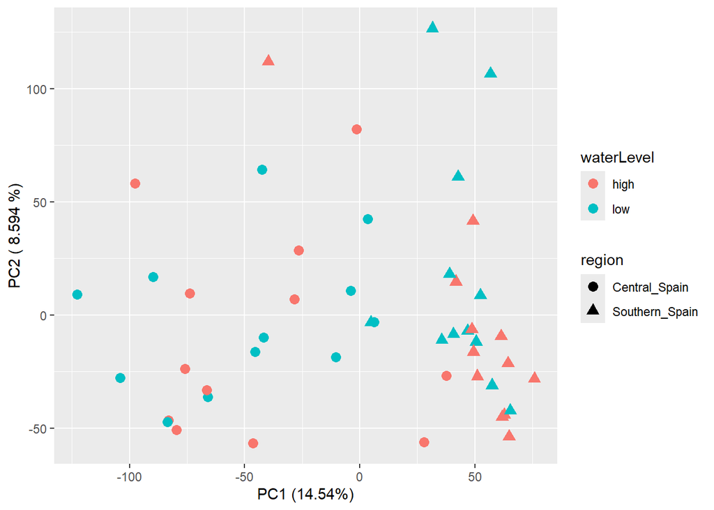

```r
# Perform PCA on transpose, scaled, centered data
pca<- prcomp(t(vst_counts),scale=T, center=T)



## add metadata and plot
pca$x %>%
  as_tibble(rownames = "sample_id") %>%
  left_join(exp_design) %>% # add the experimental design information
  ggplot(aes(x=PC1, y=PC2, color=waterLevel, shape=region)) +
  labs(x=paste0("PC1 (", summary(pca)$importance["Proportion of Variance",1]*100, "%)"),
       y=paste("PC2 (", summary(pca)$importance["Proportion of Variance",2]*100, "%)")) +
  geom_point(size=3)
```

We will repeat the process separately for each specific region in order to check for the variance within region.

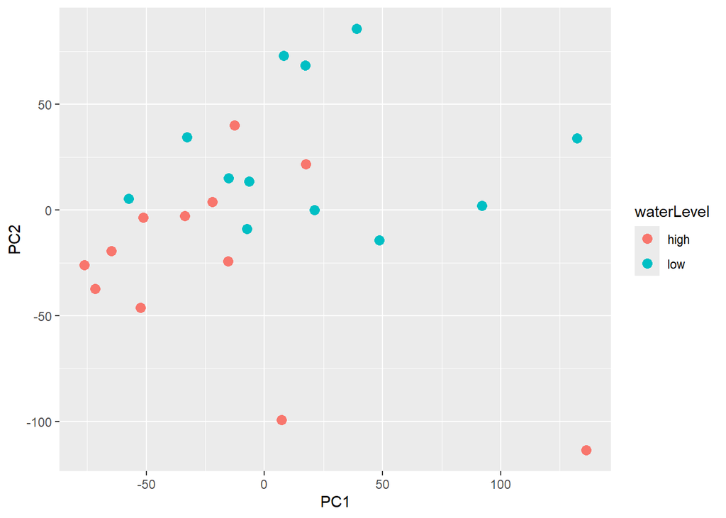

```r
vst_counts_south<- counts_matrix %>%
  as.data.frame() %>%
  select(contains(c("Esp","Jab", "Lla"))) %>%
  mutate_all(as.integer) %>%
  as.matrix() %>%
  vst()

# remove 0-variance genes
vst_counts_south<-vst_counts_south[apply(vst_counts_south, 1, var) != 0,]

# perfomr PCA on TRANSPOSED scaled, centred data
pca_south<- prcomp(t(vst_counts_south),scale.=T, center=T)

## add metadata and plot
pca_south$x %>%
  as_tibble(rownames = "sample_id") %>%
  left_join(exp_design) %>%
  ggplot(aes(x=PC1, y=PC2, color=waterLevel)) +
  geom_point(size=3)
```

There might be a slight separation in PC2 for Southern Spain populations, however, it is not very notable.

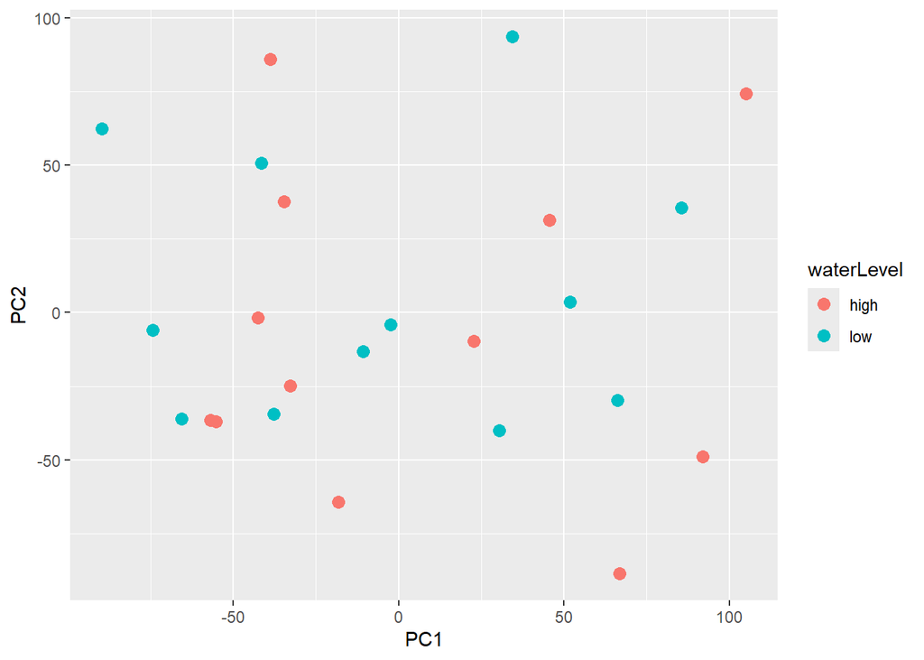

```r
vst_counts_central<- counts_matrix %>%
  as.data.frame() %>%
  select(contains(c("Bui","Can", "Tur"))) %>%
  mutate_all(as.integer) %>%
  as.matrix() %>%
  vst()

# remove 0-variance genes
vst_counts_central<-vst_counts_central[apply(vst_counts_central, 1, var) != 0,]

# perfomr PCA on TRANSPOSED scaled, centred data
pca_central<- prcomp(t(vst_counts_central),scale.=T, center=T)

## add metadata and plot
pca_central$x %>%
  as_tibble(rownames = "sample_id") %>%
  left_join(exp_design) %>%
  ggplot(aes(x=PC1, y=PC2, color=waterLevel)) +
  geom_point(size=3)
```

There is even less separation for the Central Spain populations.

Therefore, we will mainly focus on the study of the differential gene expression between regions.

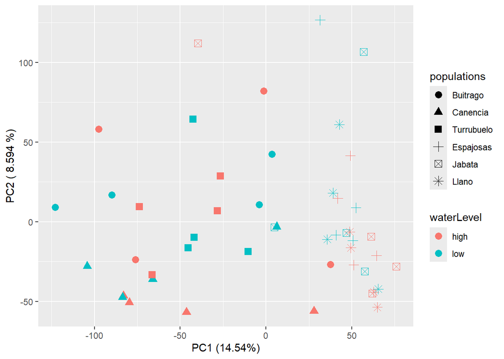

```r
pca$x %>%
  as_tibble(rownames = "sample_id") %>%
  left_join(exp_design) %>% # add the experimental design information
  ggplot(aes(x=PC1, y=PC2, color=waterLevel, shape=populations)) +
  labs(x=paste0("PC1 (", summary(pca)$importance["Proportion of Variance",1]*100, "%)"),
       y=paste("PC2 (", summary(pca)$importance["Proportion of Variance",2]*100, "%)")) +
  geom_point(size=3)
```

# Heatmaps

Heatmaps can also help visualize the clustering of the samples, but they can add one extra layer of information: the clustering of genes.

## Heatmap by samples

We have to manually calculate these heat map first, and then use those distances to inform the heatmap.

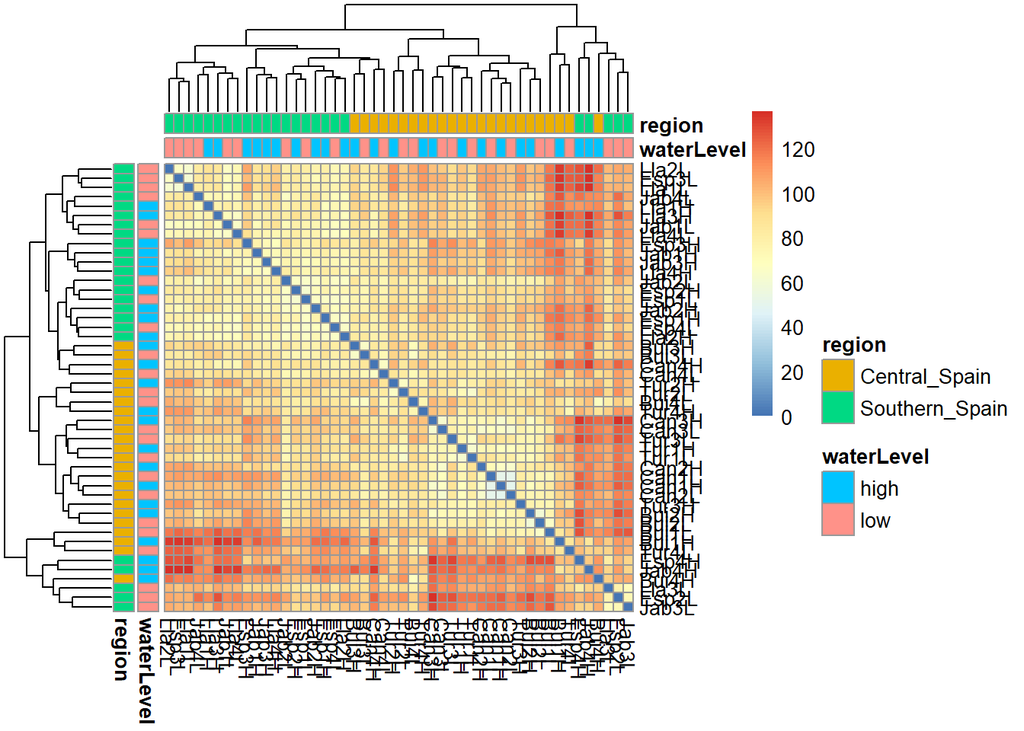

```r
# get sample-to-sample distance

sample_dist <- dist(t(vst_counts))

# convert to matrix
sample_dist_matrix <- as.matrix(sample_dist)

annotation_df <- data.frame(waterLevel = exp_design$waterLevel,
                            region = exp_design$region)

# Now, set the row names of 'annotation_df' using the 'sample_id' column from 'exp_design'.
row.names(annotation_df) <- exp_design$sample_id

# Use 'annotation_df' for both row and column annotations in 'pheatmap'.
pheatmap(sample_dist_matrix,
         annotation_col = annotation_df,
         annotation_row = annotation_df)
```

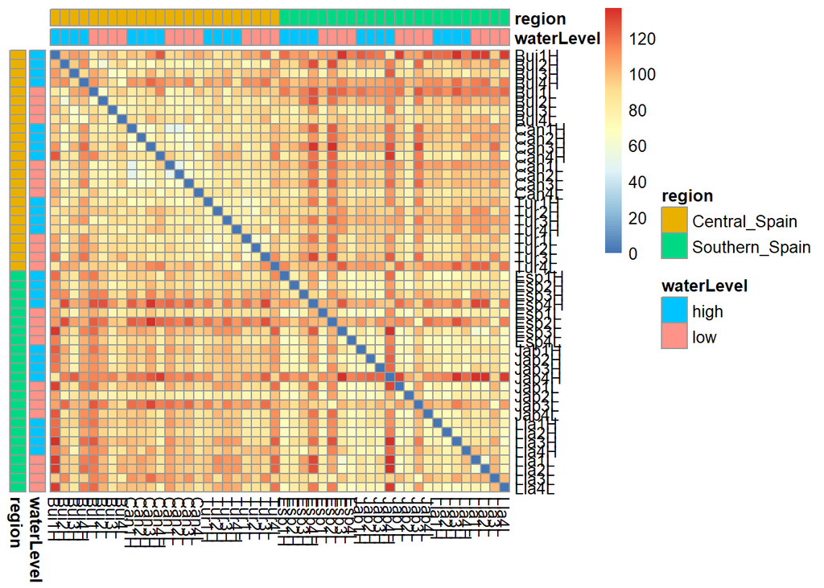

```r
pheatmap(sample_dist_matrix,
         annotation_col = annotation_df,
         annotation_row = annotation_df, cluster_rows = FALSE, cluster_cols = FALSE)
```

The color gradient from blue to red represents the range of the distances between samples (that can be interpreted as similarity or dissimilarity), with blue indicating smaller distances (samples are more similar) and red indicating larger distances (samples are less similar).

With this heat map, we would conclude something analogous to the PCA: there is greater dissimilarity between regions than between water level.

## Heatmap by genes

It is interesting to check whether there is clustering of gene expression for specific genes/transcripts. Because there are thousands of genes, we may want to only focus on genes that are particularly variable in their expression across the samples.

```r
# Sort the rows in vst matrix by the row-wise variance, and keep only the 500 most variable genes

var_genes <- apply(vst_counts,MAR=1, FUN=var) %>%
  enframe() %>%
  arrange(desc(value)) %>%
  slice_head(n=500) %>%
  pull(name)

head(var_genes) # list of genes we want to keep
```

```
## [1] "PECUL23A051951" "PECUL23A002773" "PECUL23A042291" "PECUL23A060758"
## [5] "PECUL23A016901" "PECUL23A002310"
```

```r
vst_subset<-vst_counts[var_genes, ]

# check to see we really only have 500 genes
dim(vst_subset)
```

```
## [1] 500  48
```

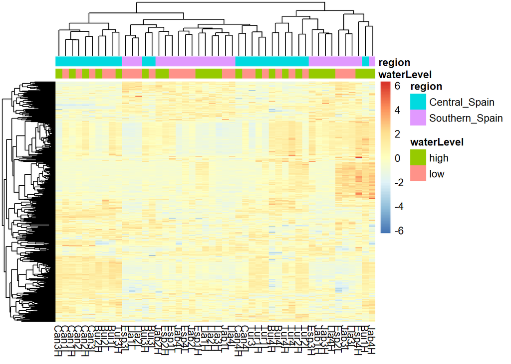

```r
pheatmap(vst_subset,
         scale = "row",
         cluster_rows=T, show_rownames=F,
         cluster_cols=T, show_colnames = T,
         annotation_col=data.frame(exp_design[,c("sample_id","waterLevel","region")], row.names = "sample_id"))
```

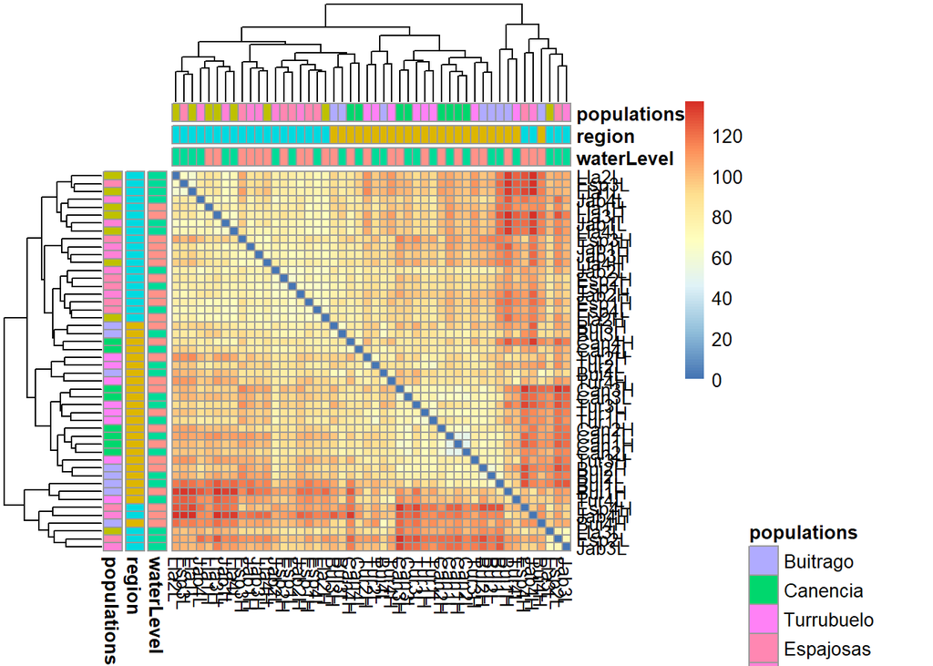

```r
# get sample-to-sample distance

sample_dist <- dist(t(vst_counts))

# convert to matrix
sample_dist_matrix <- as.matrix(sample_dist)

annotation_df <- data.frame(waterLevel = exp_design$waterLevel,
                            region = exp_design$region, populations=exp_design$populations)

# Now, set the row names of 'annotation_df' using the 'sample_id' column from 'exp_design'.
row.names(annotation_df) <- exp_design$sample_id

# Use 'annotation_df' for both row and column annotations in 'pheatmap'.
pheatmap(sample_dist_matrix,
         annotation_col = annotation_df,
         annotation_row = annotation_df)
```

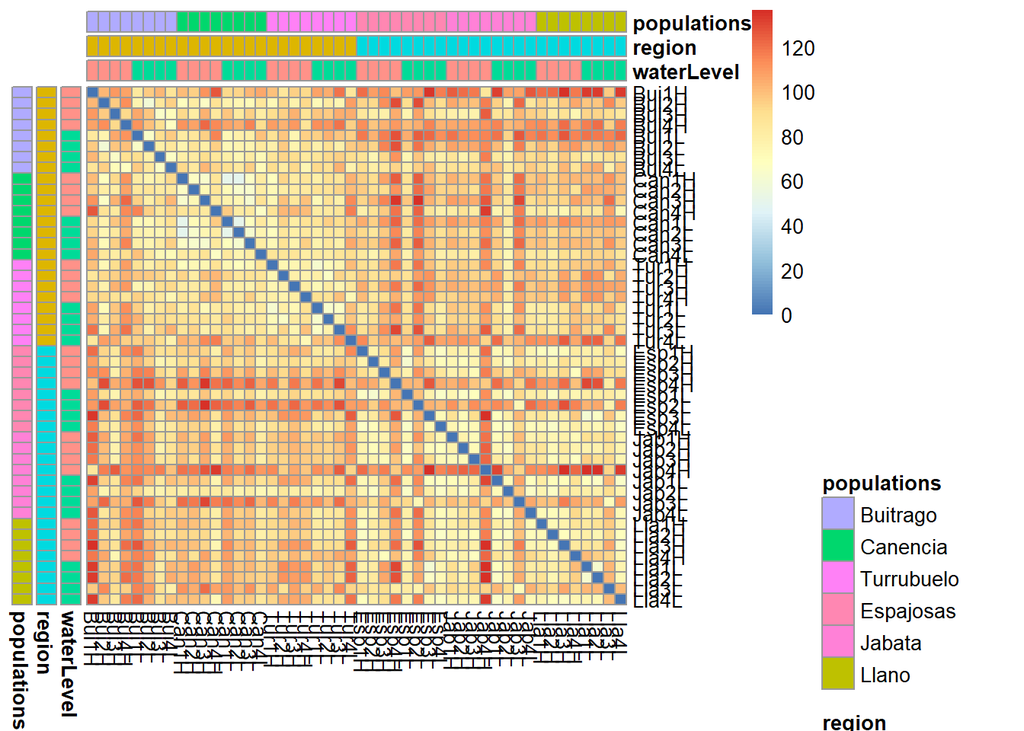

```r
pheatmap(sample_dist_matrix,
         annotation_col = annotation_df,
         annotation_row = annotation_df, cluster_rows = FALSE, cluster_cols = FALSE)
```